# Apply 5

Predicting Board Game Ratings

Our modeling goal is to predict ratings for board games based on the main characteristics like number of players and game category. How are the ratings distributed?

# 1 Explore Data

```r
library(tidyverse)
ratings <- read_csv("https://raw.githubusercontent.com/rfordatascience/tidytuesday/master/data/2022/2022-01-25/ratings.csv")
details <- read_csv("https://raw.githubusercontent.com/rfordatascience/tidytuesday/master/data/2022/2022-01-25/details.csv")
```

Join the data

```r
ratings_joined <- ratings %>%
    left_join(details, by = "id")
```

Create a binary target variable

```r
# Is it top 25% in average rating?

ratings_cat <- ratings_joined %>% mutate(is_top_25 = if_else(average > 7.04, "yes", "no"))
skimr::skim(ratings_cat)
```

Data summary

| Name | ratings_cat |
| --- | --- |
| Number of rows | 21831 |
| Number of columns | 33 |
| _______________________ |  |
| Column type frequency: |  |
| character | 14 |
| numeric | 19 |
| ________________________ |  |
| Group variables | None |

**Variable type: character**

| skim_variable | n_missing | complete_rate | min | max | empty | n_unique | whitespace |
| --- | --- | --- | --- | --- | --- | --- | --- |
| name | 0 | 1.00 | 1 | 107 | 0 | 21432 | 0 |
| url | 0 | 1.00 | 16 | 68 | 0 | 21831 | 0 |
| thumbnail | 6 | 1.00 | 135 | 139 | 0 | 21816 | 0 |
| primary | 200 | 0.99 | 1 | 107 | 0 | 21236 | 0 |
| description | 201 | 0.99 | 49 | 16144 | 0 | 21615 | 0 |
| boardgamecategory | 483 | 0.98 | 8 | 216 | 0 | 6730 | 0 |
| boardgamemechanic | 1790 | 0.92 | 8 | 478 | 0 | 8291 | 0 |
| boardgamefamily | 3961 | 0.82 | 13 | 2768 | 0 | 11285 | 0 |
| boardgameexpansion | 16325 | 0.25 | 7 | 18150 | 0 | 5264 | 0 |
| boardgameimplementation | 16969 | 0.22 | 6 | 890 | 0 | 4247 | 0 |
| boardgamedesigner | 796 | 0.96 | 7 | 332 | 0 | 9136 | 0 |
| boardgameartist | 6107 | 0.72 | 6 | 8408 | 0 | 9080 | 0 |
| boardgamepublisher | 201 | 0.99 | 6 | 3744 | 0 | 11265 | 0 |
| is_top_25 | 0 | 1.00 | 2 | 3 | 0 | 2 | 0 |

**Variable type: numeric**

| skim_variable | n_missing | complete_rate | mean | sd | p0 | p25 | p50 | p75 | p100 | hist |
| --- | --- | --- | --- | --- | --- | --- | --- | --- | --- | --- |
| num.x | 0 | 1.00 | 10915.00 | 6302.21 | 0.00 | 5457.50 | 10915.00 | 16372.50 | 21830.00 | ▇▇▇▇▇ |
| id | 0 | 1.00 | 118144.78 | 105369.55 | 1.00 | 12308.50 | 104994.00 | 207219.00 | 350992.00 | ▇▂▃▃▂ |
| year | 0 | 1.00 | 1987.44 | 193.51 | 0.00 | 2001.00 | 2011.00 | 2017.00 | 3500.00 | ▁▁▇▁▁ |
| rank | 0 | 1.00 | 10916.00 | 6302.21 | 1.00 | 5458.50 | 10916.00 | 16373.50 | 21831.00 | ▇▇▇▇▇ |
| average | 0 | 1.00 | 6.42 | 0.93 | 1.04 | 5.83 | 6.45 | 7.04 | 9.57 | ▁▁▅▇▁ |
| bayes_average | 0 | 1.00 | 5.68 | 0.36 | 0.00 | 5.51 | 5.54 | 5.67 | 8.51 | ▁▁▁▇▁ |
| users_rated | 0 | 1.00 | 866.96 | 3679.82 | 30.00 | 56.00 | 122.00 | 392.00 | 108975.00 | ▇▁▁▁▁ |
| num.y | 200 | 0.99 | 10815.00 | 6244.48 | 0.00 | 5407.50 | 10815.00 | 16222.50 | 21630.00 | ▇▇▇▇▇ |
| yearpublished | 200 | 0.99 | 1986.09 | 210.04 | -3500.00 | 2001.00 | 2011.00 | 2017.00 | 2023.00 | ▁▁▁▁▇ |
| minplayers | 200 | 0.99 | 2.01 | 0.69 | 0.00 | 2.00 | 2.00 | 2.00 | 10.00 | ▇▁▁▁▁ |
| maxplayers | 200 | 0.99 | 5.71 | 15.10 | 0.00 | 4.00 | 4.00 | 6.00 | 999.00 | ▇▁▁▁▁ |
| playingtime | 200 | 0.99 | 90.51 | 534.83 | 0.00 | 25.00 | 45.00 | 90.00 | 60000.00 | ▇▁▁▁▁ |
| minplaytime | 200 | 0.99 | 63.65 | 447.21 | 0.00 | 20.00 | 30.00 | 60.00 | 60000.00 | ▇▁▁▁▁ |
| maxplaytime | 200 | 0.99 | 90.51 | 534.83 | 0.00 | 25.00 | 45.00 | 90.00 | 60000.00 | ▇▁▁▁▁ |
| minage | 200 | 0.99 | 9.61 | 3.64 | 0.00 | 8.00 | 10.00 | 12.00 | 25.00 | ▂▇▆▁▁ |
| owned | 200 | 0.99 | 1487.92 | 5395.08 | 0.00 | 150.00 | 322.00 | 903.50 | 168364.00 | ▇▁▁▁▁ |
| trading | 200 | 0.99 | 43.59 | 102.41 | 0.00 | 5.00 | 13.00 | 38.00 | 2508.00 | ▇▁▁▁▁ |
| wanting | 200 | 0.99 | 42.03 | 117.94 | 0.00 | 3.00 | 9.00 | 29.00 | 2011.00 | ▇▁▁▁▁ |
| wishing | 200 | 0.99 | 233.66 | 800.66 | 0.00 | 14.00 | 39.00 | 131.00 | 19325.00 | ▇▁▁▁▁ |

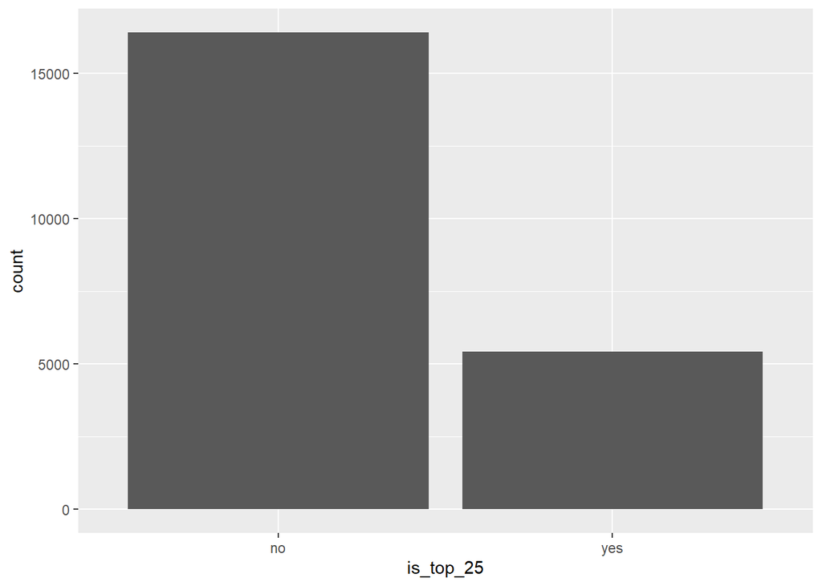

```r
ratings_cat %>%
    ggplot(aes(is_top_25)) +
    geom_bar()
```

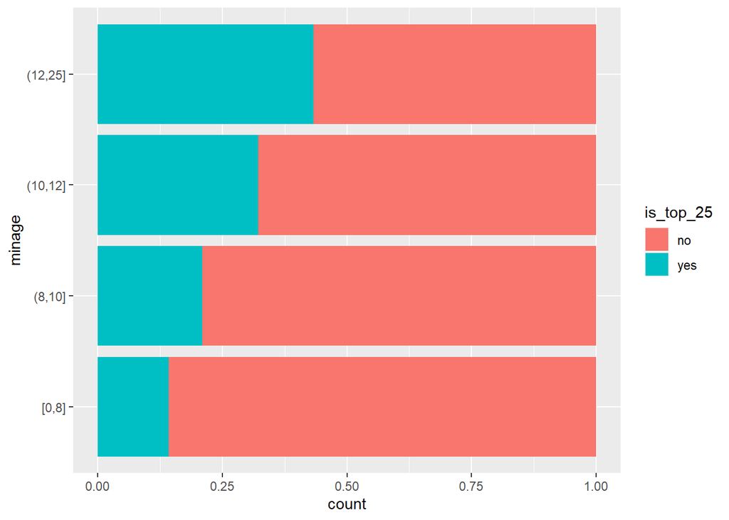

```r
ratings_cat %>%
    filter(!is.na(minage)) %>%
    mutate(minage = cut_number(minage, 4)) %>%
    ggplot(aes(y = minage, fill = is_top_25)) +
    geom_bar(position = "fill")
```

# 2 Tune an xgboost model

xgboost would be a good fit for a large dataset like this. It throws a large sets of hyperparameters and see which one sticks. split

```r
library(tidymodels)
set.seed(123)
game_split <- ratings_cat %>%
    select(name, is_top_25, matches("min|max"), boardgamecategory) %>%
    na.omit() %>%
    initial_split(strata = is_top_25)

game_train <- training(game_split)
game_test  <- testing(game_split)

set.seed(234)
game_folds <- rsample::vfold_cv(game_train, strata = is_top_25)
game_folds
```

```
## #  10-fold cross-validation using stratification
## # A tibble: 10 × 2
##    splits               id
##    <list>               <chr>
##  1 <split [14409/1601]> Fold01
##  2 <split [14409/1601]> Fold02
##  3 <split [14409/1601]> Fold03
##  4 <split [14409/1601]> Fold04
##  5 <split [14409/1601]> Fold05
##  6 <split [14409/1601]> Fold06
##  7 <split [14409/1601]> Fold07
##  8 <split [14409/1601]> Fold08
##  9 <split [14409/1601]> Fold09
## 10 <split [14409/1601]> Fold10
```

feature engineering

```r
library(textrecipes)

split_category <- function(x) {

    x %>%
        str_split(", ") %>%
        # map(.x = ., .f = ~str_remove_all(.x, "[:punct:]")) %>%
        # map(~str_remove_all(.x, "[:punct:]")) %>%
        map(str_remove_all, "[:punct:]") %>%
        map(str_squish) %>%
        map(str_to_lower) %>%
        map(str_replace_all, " ", "_")

}

game_rec <- recipe(is_top_25 ~ ., data = game_train) %>%
    update_role(name, new_role = "id") %>%
    step_tokenize(boardgamecategory, custom_token = split_category) %>%
    step_tokenfilter(boardgamecategory, max_tokens = 30) %>%
    step_tf(boardgamecategory)

game_prep <- prep(game_rec)
bake(game_prep, new_data = game_train)
```

```
## # A tibble: 16,010 × 37
##    name   minpl…¹ maxpl…² minpl…³ maxpl…⁴ minage is_to…⁵ tf_bo…⁶ tf_bo…⁷ tf_bo…⁸
##    <fct>    <dbl>   <dbl>   <dbl>   <dbl>  <dbl> <fct>     <int>   <int>   <int>
##  1 Forbi…       2       4      30      30     10 no            0       0       1
##  2 Munch…       3       6      60     120     10 no            0       0       0
##  3 Bohna…       2       7      45      45     13 no            0       0       0
##  4 Coup         2       6      15      15     13 no            0       0       0
##  5 Sushi…       2       5      15      15      8 no            0       0       0
##  6 Risk         2       6     120     120     10 no            0       0       0
##  7 Monop…       2       8      60     180      8 no            0       0       0
##  8 Machi…       2       4      30      30     10 no            0       0       0
##  9 Scrab…       2       4      90      90     10 no            0       0       0
## 10 BANG!        4       7      20      40     10 no            0       0       0
## # … with 16,000 more rows, 27 more variables:
## #   tf_boardgamecategory_ancient <int>, tf_boardgamecategory_animals <int>,
## #   tf_boardgamecategory_bluffing <int>, tf_boardgamecategory_card_game <int>,
## #   tf_boardgamecategory_childrens_game <int>,
## #   tf_boardgamecategory_deduction <int>, tf_boardgamecategory_dice <int>,
## #   tf_boardgamecategory_economic <int>,
## #   tf_boardgamecategory_exploration <int>, …
```

```r
library(usemodels)
use_xgboost(is_top_25 ~ ., data = game_train)
```

Model specification

```r
xgb_spec <-
  boost_tree(
    trees = tune(),
    mtry = tune(),
    min_n = tune(),
    learn_rate = 0.01
  ) %>%
  set_engine("xgboost") %>%
  set_mode("classification")
```

Workflow

```r
xgb_wf <- workflow(game_rec, xgb_spec)
xgb_wf
```

```
## ══ Workflow ════════════════════════════════════════════════════════════════════
## Preprocessor: Recipe
## Model: boost_tree()
##
## ── Preprocessor ────────────────────────────────────────────────────────────────
## 3 Recipe Steps
##
## • step_tokenize()
## • step_tokenfilter()
## • step_tf()
##
## ── Model ───────────────────────────────────────────────────────────────────────
## Boosted Tree Model Specification (classification)
##
## Main Arguments:
##   mtry = tune()
##   trees = tune()
##   min_n = tune()
##   learn_rate = 0.01
##
## Computational engine: xgboost
```

Tune

```r
library(finetune)
doParallel::registerDoParallel()

set.seed(99383)
# xgboost_tune <-
#     finetune::tune_race_anova(
#         object = xgboost_workflow,
#         game_folds,
#         grid = 5,
#         control = control_race(verbose_elim = TRUE)
#         )

xgb_game_rs <-
    tune_grid(
        xgb_wf,
        game_folds,
        grid = 2,
        control = control_grid(pkgs = c("stringr", "purrr"))
    )
```

```
## i Creating pre-processing data to finalize unknown parameter: mtry
```

# 3 Evaluate models

## 3.a View the best model

```r
collect_metrics(xgb_game_rs)
```

```
## # A tibble: 4 × 9
##    mtry trees min_n .metric  .estimator  mean     n std_err .config
##   <int> <int> <int> <chr>    <chr>      <dbl> <int>   <dbl> <chr>
## 1    10  1303    16 accuracy binary     0.808    10 0.00380 Preprocessor1_Model1
## 2    10  1303    16 roc_auc  binary     0.829    10 0.00560 Preprocessor1_Model1
## 3    31   637    30 accuracy binary     0.805    10 0.00364 Preprocessor1_Model2
## 4    31   637    30 roc_auc  binary     0.824    10 0.00593 Preprocessor1_Model2
```

```r
# collect_predictions(xgb_game_rs)

# conf_mat_resampled(xgb_game_rs, tidy = FALSE) %>%
#     autoplot()
```

## 3.b Fit the best model to train data (finalize_workflow) evaluate on test data

```r
xgb_last <-
    xgb_wf %>%
    finalize_workflow(select_best(xgb_game_rs, metric = "accuracy")) %>%
    last_fit(game_split)
```

## 3.d Collect metrics

```r
xgb_last %>% collect_metrics()
```

```
## # A tibble: 2 × 4
##   .metric  .estimator .estimate .config
##   <chr>    <chr>          <dbl> <chr>
## 1 accuracy binary         0.800 Preprocessor1_Model1
## 2 roc_auc  binary         0.820 Preprocessor1_Model1
```

## 3.e Predict (extract_workflow)

```r
xgb_last %>%
    extract_workflow() %>%
    predict(game_test[1,])
```

```
## # A tibble: 1 × 1
##   .pred_class
##   <fct>
## 1 no
```

## 3.f Important variables

using the vip package (extract_fit_parsnip)

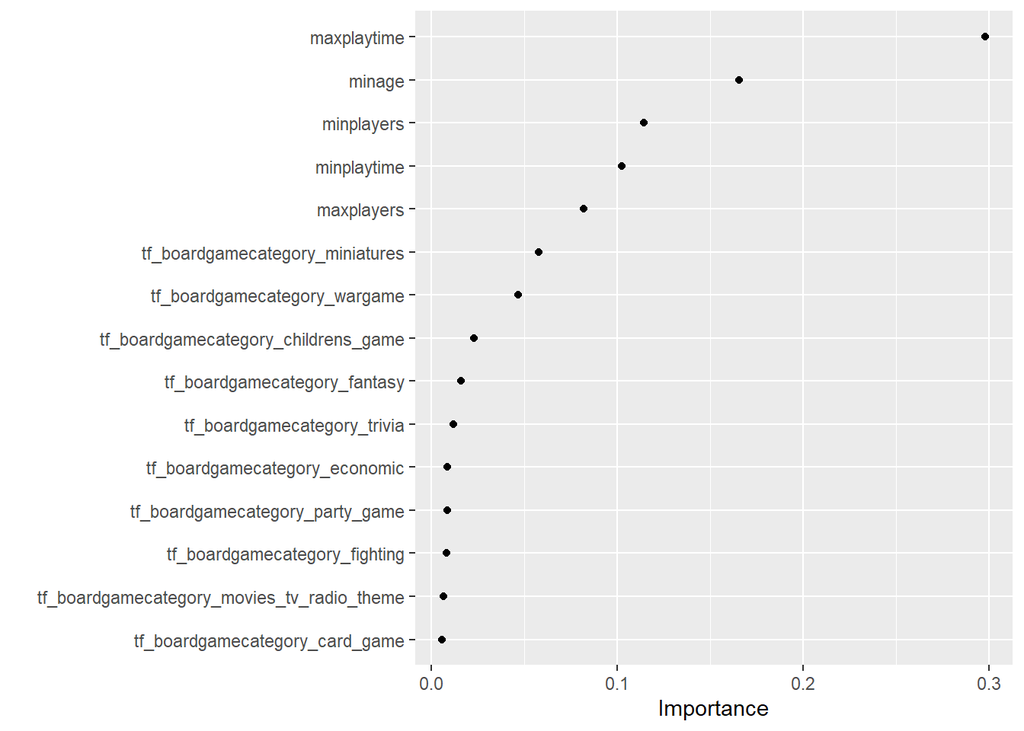

```r
library(vip)
xgb_fit <- extract_fit_parsnip(xgb_last)
vip::vip(xgb_fit, geom = "point", num_features = 15)
```

using the SHAPforxgboost package

[figure not shown]

```r
library(SHAPforxgboost)

game_shap <-
    shap.prep(
        xgb_model = extract_fit_engine(xgb_fit),
        X_train = bake(game_prep,
                       has_role("predictor"),
                       new_data = NULL,
                       composition = "matrix")
        )

shap.plot.summary(game_shap)

shap.plot.dependence(
  game_shap,
  x = "minage",
  color_feature = "minplayers",
  size0 = 1.2,
  smooth = FALSE, add_hist = TRUE
)
```

# CA Questions

1. Question and Data

1.a What is the research question?

1.b Describe the data briefly.

1.c Describe the first observation (the first row) in the data.

2. Data Exploration and Transformation

2.a What are the characteristics of the key variables used in the analysis? For example, which of the predictors seems to have correlations with the outcome variable? Does any variable have a skewed distribution, missing values, or incorrect information?

2.b Describe the differences between the original data and the data transformed for modeling. Why?

3. Data Preparation and Modeling

3.a What are the names of data preparation steps (e.g., step_dummy) mentioned in the video?

3.b What is the name of the machine learning models (e.g., random forest) used in the analysis?

3.c Describe the steps taken for data preparation. Why?

3.d Describe the characteristics of the models used in the analysis, including their advantages and disadvantages.

4. Model Evaluation

4.a What metrics are used in the model evaluation?

4.b Describe the characteristics of the metrics used in the analysis, including their advantages and disadvantages.

5. Conclusion

5.a What are the major findings?